# Drzewo klasyfikacyjne

2023-12-21

## Wprowadzenie

Celem naszego projektu jest przeprowadzenie wstępnej analizy danych, a następnie stworzenie drzewa klasyfikacyjnego dla osób przebadanych pod kątem cukrzycy oraz przeprowadzenie prognoz.

Dane pochodzą z pakietu MASS.

#### Krótko o danych

Dane dotyczą populacji kobiet z plemienia Pima w wieku co najmniej 21 lat, mieszkających w pobliżu Phoenix w Arizonie, które zostały przebadane pod kątem cukrzycy zgodnie z kryteriami Światowej Organizacji Zdrowia. Dane zebrał amerykański Narodowy Instytut Cukrzycy oraz Chorób Trawiennych i Nerek.

## Instalacja pakietów i wczytanie danych

```r
library(moments)
library(dplyr)
library(ggplot2)
library(rpart)
library(rpart.plot)
library(MASS)
library(corrplot)
library(cowplot)
library(tidyr)
data("Pima.tr")
```

#### Podział pracy

- Dariusz Różycki - aplikacja Shiny
- Justyna Sarkowicz - prezentacja

## Wyjaśnienie atrybutów

W naszej analizie skorzystaliśmy z wybranych zmiennych:

- **glu** - stężenie glukozy w osoczu w doustnym teście tolerancji glukozy
- **bp** - rozkurczowe ciśnienie krwi (mm Hg)
- **bmi** - wskaźnik masy ciała
- **age** - wiek
- **type** - zmienna wynikowa (yes - oznacza obecność cukrzycy, no - oznacza jej brak)

#### Braki danych

```r
sum(is.na(Pima.tr))
```

```
## [1] 0
```

W danych nie ma żadnych braków.

## Zapoznanie się z danymi

Wstępna obróbka danych, aby przygotować je do dalszej części analizy:

```r
Pima.tr <- Pima.tr[, -c(1,4,6)]
names(Pima.tr) <- c("Glukoza", "Ciśnienie", "BMI", "Wiek", "Cukrzyca")
head(Pima.tr)
```

| Glukoza | Ciśnienie | BMI | Wiek | Cukrzyca |
| --- | --- | --- | --- | --- |
| 86 | 68 | 30.2 | 24 | No |
| 195 | 70 | 25.1 | 55 | Yes |
| 77 | 82 | 35.8 | 35 | No |
| 165 | 76 | 47.9 | 26 | No |
| 107 | 60 | 26.4 | 23 | No |
| 97 | 76 | 35.6 | 52 | Yes |

## Korelacja

Sprawdzam korelacje danych:

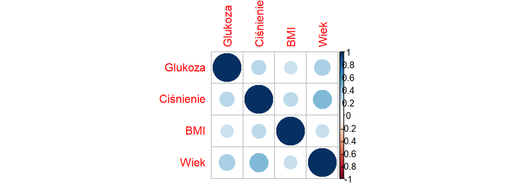

## Podstawowe statystyki

Przedstawiam podstawowe statystyki opisowe zmiennych: minimum, kwantyle, mediane, maximum, średnią, odchylenie standardowe, skośność, kurtoze:

| Zmienna | Min | Q1 | Median | Q3 | Max | Mean | SD | Skewness | Kurtosis |
| --- | --- | --- | --- | --- | --- | --- | --- | --- | --- |
| Glukoza | 56 | 100 | 120.5 | 144 | 199 | 123.97 | 31.67 | 0.45 | 2.64 |
| Ciśnienie | 38 | 64 | 70 | 78 | 110 | 71.26 | 11.48 | 0.17 | 3.54 |
| BMI | 18.2 | 27.58 | 32.8 | 36.5 | 47.9 | 32.31 | 6.13 | 0.03 | 2.59 |
| Wiek | 21 | 23 | 28 | 39.25 | 63 | 32.11 | 10.98 | 1.09 | 3.27 |

## Wykresy 1

Zobaczmy jeszcze jak to się prezentuje na wykresach pudełkowych:

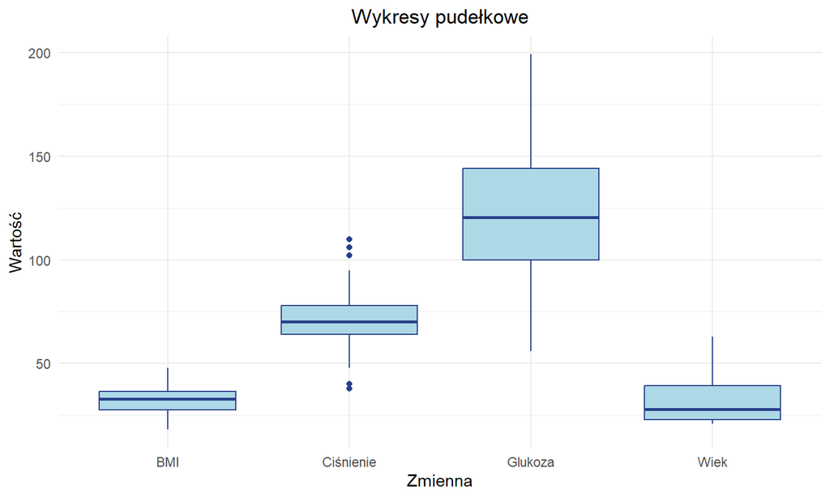

Widzimy, że przedział dla glukozy jest bardzo szeroki i pojawiło się pare wartości odstających w zmiennej ciśnienie.

## Wykresy 2

Możemy zobaczyć jeszcze jak prezentują się rozkłady na histogramach:

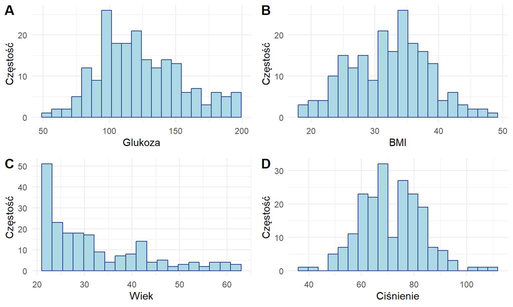

## Drzewo decyzyjne

**Drzewo klasyfikacyjne** wykorzystuje się do wyznaczania przynależności przypadków lub obiektów do klas jakościowej zmiennej zależnej na podstawie pomiarów jednej lub więcej zmiennych objaśniających (predyktorów). Analiza drzew klasyfikacyjnych jest jedną z podstawowych technik wykorzystywanych w tzw. Zgłębianiu danych. Celem analizy opartej na tym modelu jest przewidywanie lub wyjaśnianie odpowiedzi (reakcji) zakodowanych w danej zmiennej.  
Wyniki prezenetowane są w postaci grafu.

## Sposób tworzenia drzewa

1. **Budowa Drzewa**: Algorytm zaczyna od korzenia drzewa i podziela zbiór danych na podzbiory na podstawie pewnych kryteriów. Kryteria te są wybierane w sposób, który maksymalizuje jednolitość wewnątrz podgrup i jednocześnie minimalizuje zróżnicowanie między nimi.
2. **Podział na Węzły**: Każdy węzeł w drzewie reprezentuje test na jednej zmiennych. W zależności od wyniku tego testu, obserwacje są kierowane w dół drzewa, do lewego lub prawego poddrzewa.
3. **Liście Drzewa**: Końcowe węzły, zwane liśćmi, reprezentują prognozy dla danych. Dla problemu klasyfikacji liście oznaczają przewidywane klasy, a dla regresji reprezentują przewidywane wartości numeryczne.
4. **Proces Rekurencyjny**: Proces podziału i budowy drzewa jest powtarzany rekurencyjnie aż do osiągnięcia pewnego warunku zatrzymującego, takiego jak maksymalna głębokość drzewa, minimalna liczba próbek w liściu, czy brak dalszych podziałów poprawiających model.

## Podjęcie decyzji

Informacje o podziale drzewa dla zmiennej **Cukrzyca**:

```
## n= 200
##
## node), split, n, loss, yval, (yprob)
##       * denotes terminal node
##
##  1) root 200 68 No (0.66000000 0.34000000)
##    2) Glukoza< 123.5 109 15 No (0.86238532 0.13761468)
##      4) Wiek< 28.5 74  4 No (0.94594595 0.05405405) *
##      5) Wiek>=28.5 35 11 No (0.68571429 0.31428571)
##       10) Glukoza< 90 9  0 No (1.00000000 0.00000000) *
##       11) Glukoza>=90 26 11 No (0.57692308 0.42307692)
##         22) Ciśnienie>=68 19  6 No (0.68421053 0.31578947) *
##         23) Ciśnienie< 68 7  2 Yes (0.28571429 0.71428571) *
##    3) Glukoza>=123.5 91 38 Yes (0.41758242 0.58241758)
##      6) BMI< 28.65 21  5 No (0.76190476 0.23809524) *
##      7) BMI>=28.65 70 22 Yes (0.31428571 0.68571429)
##       14) Glukoza< 166 50 20 Yes (0.40000000 0.60000000)
##         28) Glukoza>=153 14  5 No (0.64285714 0.35714286) *
##         29) Glukoza< 153 36 11 Yes (0.30555556 0.69444444) *
##       15) Glukoza>=166 20  2 Yes (0.10000000 0.90000000) *
```

## Drzewo

Drzewo klasyfikacyjnego dla zmiennej **Cukrzyca**

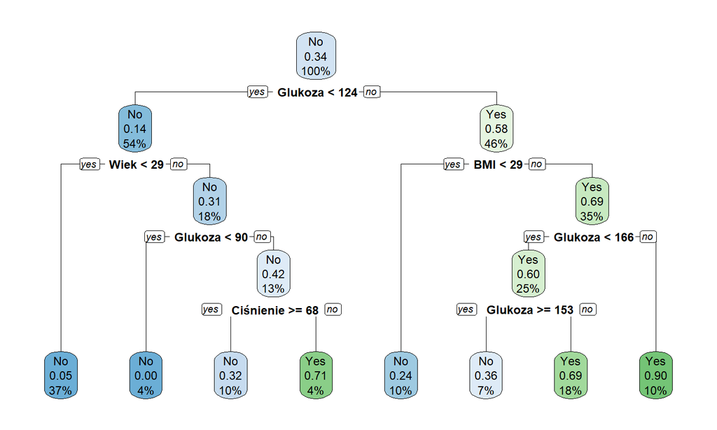

## Wnioski

[figure not shown]

- W największej grupie ryzyka zachorowania na cukrzycę są osoby, które mają wysoki poziom glukozy (powyżej 124) oraz wysokie BMI (powyżej 29). W większości przypadków osoby te chorują na cukrzyce. Warto zauważyć, że w tej grupie decyzja o cukrzycy jest często trafna.
- Drzewo decyzyjne sugeruje, że osoby młodsze (poniżej 29 lat) z niskim poziomem glukozy (poniżej 124) mają tendencję do mniejszego ryzyka cukrzycy.

## Prognoza

Przeprowadzenia prognozy:

```r
newdata <- Pima.tr
table(Pima.tr$Cukrzyca, predict(tree, Pima.tr, type = "class"))
```

```
##
##        No Yes
##   No  117  15
##   Yes  20  48
```

Prognozy dla osób o następujących parametrach:

| Osoba | Ciśnienie | BMI | Wiek | Glukoza |
| --- | --- | --- | --- | --- |
| 1 | 150 | 30 | 70 | 63 |
| 2 | 120 | 40 | 18 | 170 |
| 3 | 50 | 23 | 40 | 140 |
| 4 | 40 | 47 | 52 | 180 |

```
##   1   2   3   4
##  No Yes  No Yes
## Levels: No Yes
```

## Obsługa shiny

#### Panel boczny

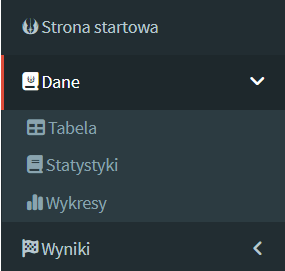

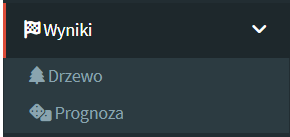

#### Funkcjonalności

- **Tabela** - wyświetla interaktywną tabele z danymi.
- **Statystyki** - wyświetla statystyki opisowe, dla zmiennej wybranej przez użytkownika
- **Wykresy** - wyświetla wykresy, dla zmiennej wybranej przez użytkownika. Dostępnę są również do wyboru różne typy wykresów (pudełkowy, histigram, gęstości, macierz korealacji), które w zależności od typu posiadają dodatkowe pozwalające użytkownikowi dopasować wygląd do jego potrzeb.
- **Drzewo** - wyświetla drzewo klasyfikacyjno-regresyjne
- **Prognoza** - interaktywna prognoza cukrzycy, w zależności od wybranych parametrów przez użytkownika

## Bibliografia

- https://www.statsoft.pl/textbook/stathome_stat.html?https%3A%2F%2Fwww.statsoft.pl%2Ftextbook%2Fstcart.html
- https://predictivesolutions.pl/wykorzystanie-drzew-regresyjnych-do-analizy-wartosci-zakupow-cz-1
- https://www.statystyka.az.pl/analiza-skupien/metoda-cart.php